# A Crash Course in R

### Subsetting Data

Suppose we want to access a single variable in our data set, there are a few different ways we can do so:

```r
sale_price1 <- my_data$sale.amount # The $ accesses the variable named 'sale.amount' within 'my.data'
sale_price2 <- my_data[,1] # We can also use indexing to access 'sale.amount'

# Notice how we specified second dimension of 'my.data' (its columns)
head(sale_price1)
```

```
## [1] 172500  90000 168500 205000 121000 215000
```

```r
head(sale_price2)
```

```
## [1] 172500  90000 168500 205000 121000 215000
```

Suppose we want to access a single case (subject) in our dataset:

```r
first_house <- my_data[1,] # This stores the entire first row
head(first_house)
```

```
##   sale.amount sale.date           occupancy         style built bedrooms
## 1      172500  1/3/2005 116 (Zero Lot Line) 1 Story Frame  1993        3
##   bsmt  ac attic area.base area.add area.bsmt area.garage1 area.garage2
## 1 Full Yes  None      1102        0       925          418            0
##   area.living area.lot       lon      lat assessed
## 1        1102     5520 -91.50913 41.65116   173040
```

Suppose we want a range of cases:

```r
firstfive_houses <- my_data[1:5,] # This stores the first five rows
head(firstfive_houses)
```

```
##   sale.amount sale.date                            occupancy
## 1      172500  1/3/2005                  116 (Zero Lot Line)
## 2       90000  1/5/2005                    113 (Condominium)
## 3      168500 1/12/2005 101 (Single-Family / Owner Occupied)
## 4      205000 1/14/2005 101 (Single-Family / Owner Occupied)
## 5      121000 1/24/2005                    113 (Condominium)
##               style built bedrooms bsmt  ac attic area.base area.add
## 1     1 Story Frame  1993        3 Full Yes  None      1102        0
## 2     1 Story Frame  2001        2 None Yes  None       878        0
## 3 Split Foyer Frame  1976        4 Full Yes  None      1236        0
## 4 Split Foyer Frame  1995        3 Full Yes  None      1466        0
## 5     1 Story Condo  2001        2 None Yes  None      1150        0
##   area.bsmt area.garage1 area.garage2 area.living area.lot       lon
## 1       925          418            0        1102     5520 -91.50913
## 2         0            0          264         878     3718 -91.52296
## 3       700          576            0        1236     8800 -91.48231
## 4       500            0            0        1466    16720 -91.55224
## 5         0            0          528        1150     3427 -91.57814
##        lat assessed
## 1 41.65116   173040
## 2 41.67324    89470
## 3 41.65849   164230
## 4 41.64900   211890
## 5 41.65263   115430
```

### Logical Conditions and Subsetting

Suppose we want know which elements of sale.amount are larger than $200,000:

```r
my_data$sale.amount > 200000 # Logical vector for the condition "> 200000"
which(my_data$sale.amount > 200000) # Positions of elements where the condition is "TRUE"
```

[output not shown]

Logical conditions are particularly useful for subsetting objects, here are a few examples:

```r
large_and_expensive <- my_data[my_data$sale.amount > 500000 & my_data$area.living > 3000,]
```

The example above creates a new object containing all homes that sold for more than $ 500,000 and have living areas over 3,000 square feet.

```r
nobsmt_or_noac <- my_data[my_data$bsmt == "None" | my_data$ac != "Yes",]
dim(nobsmt_or_noac)
```

```
## [1] 239  19
```

The example above creates a new object containing all homes that don’t have a basement *or* don’t have air conditioning

```r
nobsmt_and_noac <- my_data[my_data$bsmt == "None" & my_data$ac != "Yes",]
dim(nobsmt_and_noac)
```

```
## [1] 14 19
```

The example above creates a new object containing homes that don’t have a base *and* don’t have air conditioning. Pay careful attention to the difference between this example and the prior example.

**Question #5**: In your *R Script* “Lab1_Name1_Name2”, on a new line add the comment “Question 5” and on the line(s) below write code that create a new data.frame called “election_losers” that subsets “election_data” (which you created in Question 4) to include only rows where the result was “Lost”.

## Summarizing Data

### Tables, Bar Charts and Histograms

One-way frequency tables summarize a single categorical (factor) variable, while two-way frequencies tables summarize the relationship between two categorical variables. Both of these summaries can be created by the “table” function:

```r
table(my_data$style) # A one-way frequency table of 'style'
```

```
##
## 1 1/2 Story Frame     1 Story Brick     1 Story Condo     1 Story Frame
##                25                24                45               347
##     2 Story Brick     2 Story Condo     2 Story Frame Split Foyer Frame
##                10                27               184                84
## Split Level Frame
##                31
```

```r
table(my_data$bedrooms, my_data$bsmt) # A two-way frequency table of 'bedrooms' and 'bsmt'
```

```
##
##     1/2 3/4 Crawl Full None
##   1   1   0     0    6   10
##   2   2   0     1  116  120
##   3   2   0     0  250   43
##   4   1   1     0  163    5
##   5   0   0     0   47    1
##   6   0   0     0    5    0
##   7   0   0     0    3    0
```

```r
# Notice that 'bedrooms' is stored as a numeric variable,
# but it still can be used in the table function
```

Tables are their own type of object, they can be used by functions like “barplot”:

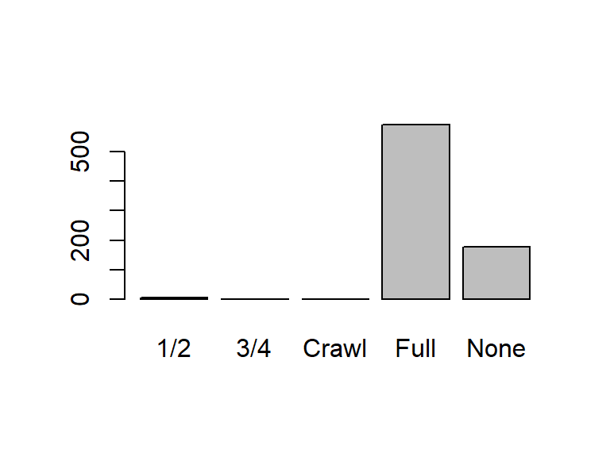

```r
my_table <- table(my_data$bsmt) # Tables can be stored as objects
barplot(my_table) # Creates a bar plot from a table
```

We can construct basic visuals of numeric variables too:

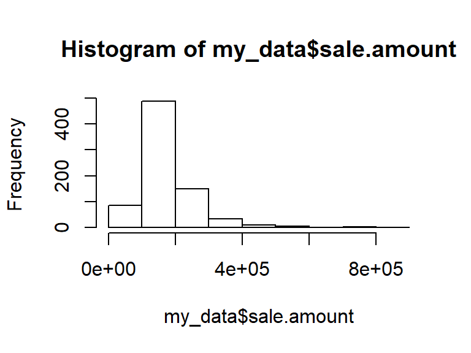

```r
hist(my_data$sale.amount) # Histograms are for numeric variables
```

Later on we will cover how to produce more elagant visuals, but these functions are useful for quick exploratory analyses.

### Numeric Summaries

Below are some examples showing how to calculate a few common summary statistics:

```r
mean(my_data$sale.amount) # mean
```

```
## [1] 180098.3
```

```r
sd(my_data$sale.amount) # standard deviation
```

```
## [1] 90655.31
```

```r
min(my_data$sale.amount) # minimum
```

```
## [1] 38250
```

```r
max(my_data$sale.amount) # maximum
```

```
## [1] 815000
```

```r
quantile(my_data$sale.amount, .35) # the 35th percentile
```

```
##    35%
## 139740
```

The `summary` function conveniently provides many of these statistics all at once:

```r
summary(my_data$sale.amount)
```

```
##    Min. 1st Qu.  Median    Mean 3rd Qu.    Max.
##   38250  130000  157900  180098  205000  815000
```

**Question #6**: In your *R Script* “Lab1_Name1_Name2”, on a new line add the comment “Question 6” and on the line(s) below write code that finds the range of the variable “Approval” using the data.frame “election_losers” (which you created in Question 5).

## Packages

To facilitate more complex tasks in `R`, many people have developed their own sets of functions known as *packages*. If you are working on your own computer, packages will need to be installed:

```r
install.packages("ggplot2")
```

Once a package is installed it still needs to be loaded using the `library` (or `require`) function in order to be used. You’ll need to load a package *every time* you open `RStudio`, but you’ll *only need to install it once*.

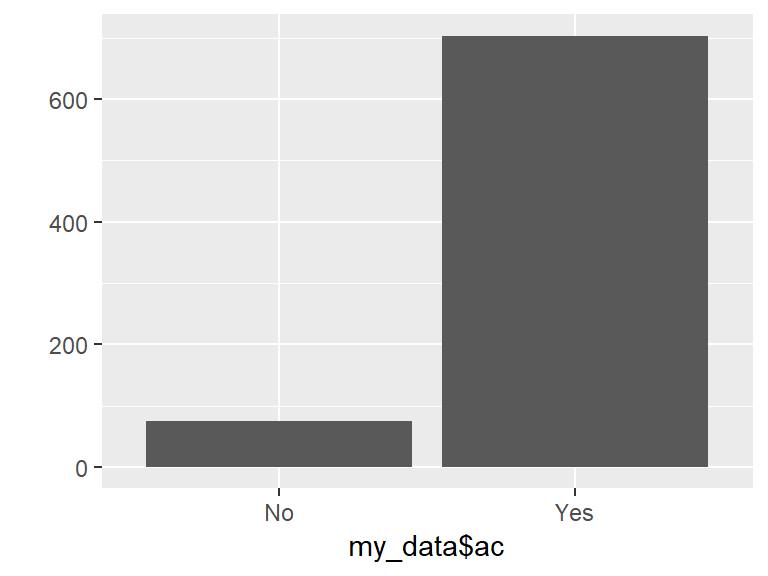

```r
library(ggplot2)
qplot(my_data$ac) # qplot is a function in the package ggplot2
```

If you are working on the Grinnell RStudio Server, you will be unable to install packages; however, almost all of the packages you’ll are already installed on the server.

## R Markdown

At the beginning of this document you were instructed to open a file called an “R Script”. This type of file is designed to contain only `R` code and comments.

`R Studio` also supports many other types of files, some of which utilize an authoring framework known as “R Markdown”. RMarkdown conveniently allows you to both:

1. Save and execute `R` code
2. Generate high quality, reproducible reports that can be shared with an audience

To use R Markdown you might need to install and load the `rmarkdown` package:

```r
install.packages("rmarkdown")
library("rmarkdown")
```

If you have the package installed and loaded, you’ll be able to create RMarkdown files by selecting: File -> New File -> R Markdown. Go ahead and try this, hitting “Ok” to use the default options.

- Your new RMarkdown file should look a lot like an RScript. The first thing you should notice is the header, which is initiated by three ‘-’ characters and closed by another three ‘-’ characters. The header contains information that will appear at the top of your compiled report.
- The second thing you’ll see is a block of code initiated by $\text{```\{r setup\}}$ and closed by $\text{```}$. This just sets up some options used when executing your `R` code when your report is built, for now you can ignore it.
- Next you’ll see section headers defined by the $\#$ character. The number of $\#$ characters determines the level (size) of the header.
- Finally you’ll see some blocks of code initiated by $\text{```\{r\}}$ and closed by $\text{```}$. These are bits of `R` code that can be executed by clicking on the green arrow in the upper right corner of the code box. You can execute smaller pieces of code within these blocks by highlighting them and hitting *Ctrl-Enter*.

To compile your R Markdown file into a polished report you need to “Knit” the file. You can do this by clicking on the “Knit” button (the yarn ball icon) located towards the upper left of screen.

### More on R Markdown

The information in the prior section provides a very brief introduction R Markdown, I encourage you to go through the lessons created by RMarkdown’s developers at https://rmarkdown.rstudio.com/lesson-1.html if you have the time. These lessons include numerous screen shots, videos, and more detailed explanations of exactly how RMarkdown works and what it is capable of.

In this class you will be expected to submit all future homework assignments and labs as compiled R Markdown documents. On the first few assignments I will provide you a template for doing so, but later on you’ll be expected to create these documents by yourself, so it is to your advantage to learn about R Markdown now if you have the time.